# Data Analysis & Modelling

Rose Porta and Clara Li

4/11/2020

```r
# bringing in data from appendix
data <- read.csv("filename.csv")

library(tidyverse)
library(broom)
library(gtools)
# Fit full model with BMI as response (secondary hypothesis)
model_full <- lm(data = data, log(BMI) ~ HRSLEEP + worfreq_binary + I(HRSLEEP*worfreq_binary) + log(AGE) + activity_score + SEX + income_high + income_middle + health_binary + race_asian + race_black + race_na)

summary(model_full)
```

```
##
## Call:
## lm(formula = log(BMI) ~ HRSLEEP + worfreq_binary + I(HRSLEEP *
##     worfreq_binary) + log(AGE) + activity_score + SEX + income_high +
##     income_middle + health_binary + race_asian + race_black +
##     race_na, data = data)
##
## Residuals:
##      Min       1Q   Median       3Q      Max
## -0.58686 -0.13227 -0.01037  0.12281  0.63650
##
## Coefficients:
##                               Estimate Std. Error t value Pr(>|t|)
## (Intercept)                  3.290e+00  1.602e-02 205.351  < 2e-16 ***
## HRSLEEP                     -6.995e-03  1.041e-03  -6.721 1.86e-11 ***
## worfreq_binary              -3.280e-02  1.797e-02  -1.825   0.0680 .
## I(HRSLEEP * worfreq_binary)  4.940e-03  2.558e-03   1.931   0.0535 .
## log(AGE)                     2.174e-02  3.499e-03   6.214 5.27e-10 ***
## activity_score               3.110e-05  2.402e-06  12.946  < 2e-16 ***
## SEX                         -2.431e-02  2.661e-03  -9.138  < 2e-16 ***
## income_high                  1.094e-03  3.336e-03   0.328   0.7430
## income_middle                2.276e-02  3.445e-03   6.606 4.04e-11 ***
## health_binary               -4.392e-02  4.270e-03 -10.287  < 2e-16 ***
## race_asian                  -7.999e-02  5.926e-03 -13.500  < 2e-16 ***
## race_black                   3.856e-02  4.168e-03   9.252  < 2e-16 ***
## race_na                      5.196e-02  1.125e-02   4.618 3.89e-06 ***
## ---
## Signif. codes:  0 '***' 0.001 '**' 0.01 '*' 0.05 '.' 0.1 ' ' 1
##
## Residual standard error: 0.1856 on 19848 degrees of freedom
## Multiple R-squared:  0.0492, Adjusted R-squared:  0.04862
## F-statistic: 85.58 on 12 and 19848 DF,  p-value: < 2.2e-16
```

Multiple Regression Model:

$log(BMI) = \beta_0 + \beta_1\cdot HRSLEEP + \beta_2\cdot worfreq\_binary + \beta_3\cdot HRSLEEP\cdot worfreq\_binary + \beta_4\cdot log(AGE) + \beta_5\cdot activity\_score + \beta_6\cdot SEX + \beta_7\cdot income\_high + \beta_8\cdot income\_middle + \beta_9\cdot health\_binary + \beta_10\cdot race\_asian + \beta_11\cdot race\_black + \beta_12\cdot race\_na$

Fitted Model:

$\widehat{log(BMI)} = \hat{\beta_0} + \hat{\beta_1}\cdot HRSLEEP + \hat{\beta_2}\cdot worfreq\_binary + \hat{\beta_3}\cdot HRSLEEP\cdot worfreq\_binary + \hat{\beta_4}\cdot log(AGE) + \hat{\beta_5}\cdot activity\_score + \hat{\beta_6}\cdot SEX + \hat{\beta_7}\cdot income\_high + \hat{\beta_8}\cdot income\_middle + \hat{\beta_9}\cdot health\_binary + \hat{\beta_10}\cdot race\_asian + \hat{\beta_11}\cdot race\_black + \hat{\beta_12}\cdot race\_na$

$\widehat{log(BMI)} = 3.290 + -0.006995\cdot HRSLEEP + -0.03280\cdot worfreq\_binary + 0.004940\cdot HRSLEEP\cdot worfreq\_binary + 0.02174\cdot log(AGE) + 0.00003110\cdot activity\_score + -0.02431\cdot SEX + 0.001094\cdot income\_high + 0.02276\cdot income\_middle + -0.04392\cdot health\_binary + -0.07999\cdot race\_asian + 0.03856\cdot race\_black + 0.05196\cdot race\_na$

# Check Regression Assumptions

## Linearity

Since our sample size is so large, it is difficult to determine from the scatterplots whether or not the relationship is linear, but there is no clear non-linear pattern, so the linearity assumption is reasonable.

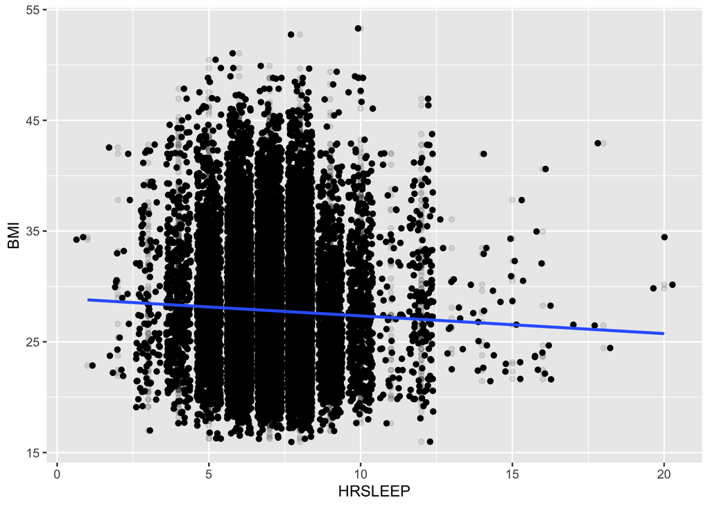

```r
# Create scatter plot of BMI versus hours of sleep
ggplot(data, aes(x = HRSLEEP, y = BMI))+
  geom_point(alpha = 0.1) +
  geom_jitter() +
  geom_smooth(method = lm, se = FALSE)
```

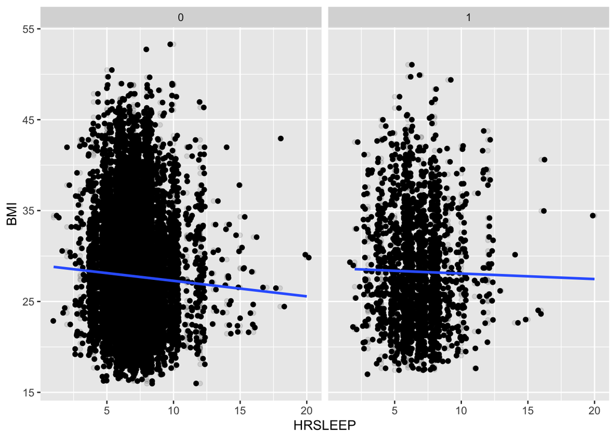

```r
# Facet scatterplot by worry frequency binary
ggplot(data, aes(x = HRSLEEP, y = BMI))+
  geom_point(alpha = 0.1) +
  geom_jitter() +
  facet_wrap(~worfreq_binary) +
  geom_smooth(method = lm, se = FALSE)
```

## Constant Variance

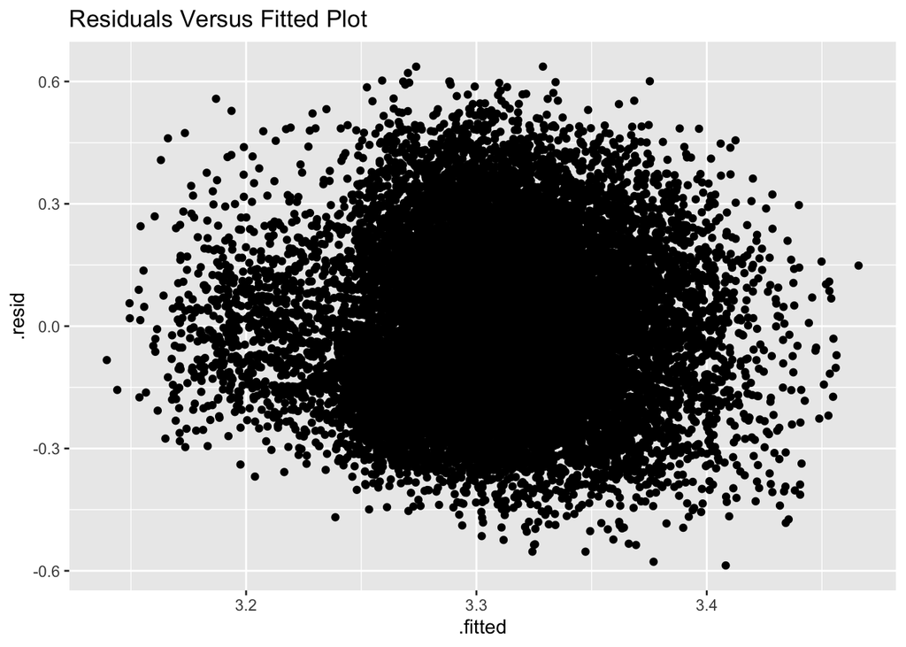

```r
# Code from Rose's Exam 1
# Creates table of residuals stored in m1_data
m1_data<-augment(model_full)

# Creates residuals vs. fitted plot
ggplot(data = m1_data, aes(x = .fitted, y = .resid))+
  geom_point()+
  labs(title = "Residuals Versus Fitted Plot")
```

## Normality

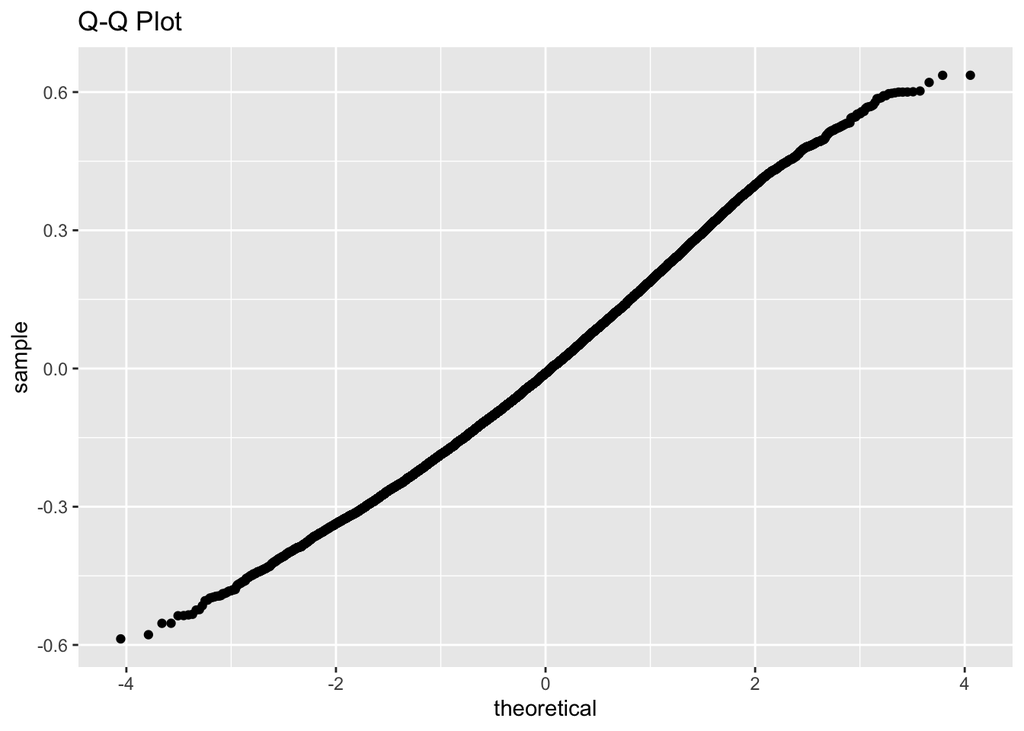

```r
# Generates Q-Q Plot
ggplot(data = m1_data, aes(sample = .resid))+
  geom_qq()+
  labs(title = "Q-Q Plot")
```

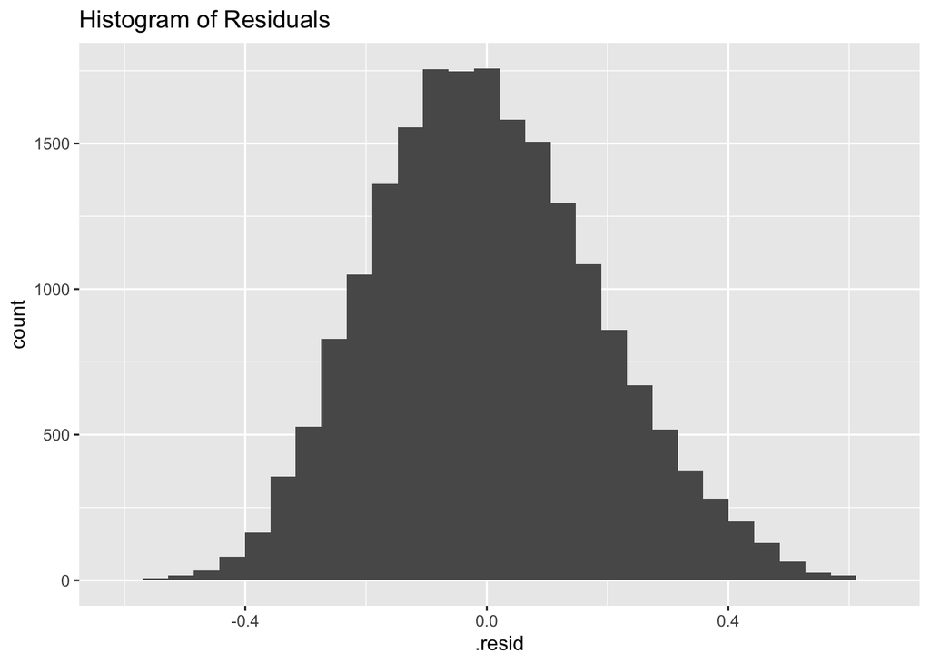

```r
# Generates histogram of residuals
ggplot(data = m1_data, aes(x = .resid))+
  geom_histogram()+
  labs(title = "Histogram of Residuals")
```

## Randomness

Our data is based on a random sample, so the randomness assumption is met.

## Independence

Only one adult from each household was chosen for the survey, so is is reasonable to assume that one sampled individual’s BMI would not impact any other sampled individual’s BMI, so independence is reasonable.

# Significance Tests:

## T-test for slope:

$\beta_1$:

$H_0: \beta_1 = 0$

$H_a: \beta_1 \ne 0$

$\alpha = 0.05$

t-value = -6.721

p-value = 1.86e-11

$\beta_2$:

$H_0: \beta_2 = 0$

$H_a: \beta_2 \ne 0$

$\alpha = 0.05$

t-value = -1.825

p-value = 0.0680

Since our p-value of 0.0680 is not less than 0.05, we cannot formally reject the null hypothesis, but it is close to the significance level, which indicates that there is some evidence that there is a significant difference between the intercepts of the regression lines predicting BMI from hours of sleep for individuals who worry daily versus those who do not, adjusting for the rest of our confounding variables.

$\beta_3$:

$H_0: \beta_3 = 0$

$H_a: \beta_3 \ne 0$

$\alpha = 0.05$

t-value = 1.931

p-value = 0.0535

Since our p-value of 0.0535 is not less than 0.05, we cannot formally reject the null hypothesis, but it is close to the significance level, which indicates that there is some evidence that there is a significant difference between the slopes of the regression lines predicting BMI from hours of sleep for individuals who worry daily versus those who do not, adjusting for the rest of our confounding variables.

## 95% Confidence Intervals

$\beta_1$: CI = (0.9910059, 0.9950576)

We are 95% confident that for each hour increase in the number of hours and individual sleeps per night, an individual’s BMI will decrease by a factor of between 0.991 and 0.995, on average, from the average BMI for an individual who gets one fewer hour of sleep per night, adjusting for worry frequency and the rest of our counfounding variables. Since our confidence interval does not include 1, this indicates that there is a significant relationship between hours of sleep and BMI.

$\beta_2$: CI = (0.9342296, 1.0024312)

We are 95% confident that adjusting for hours of sleep and the other confounding variables, the average BMI of an individual who worries daily will be between 0.934 and 1.002 times the average BMI of an individual who does not worry daily. Since our confidence interval includes 1, we cannot be certain that there is a significant difference in the average BMI for individuals who worry daily versus those who do not.

$\beta_3$: CI = (0.9999254, 1.0100036)

We are 95% confident that adjusting for our confounding variables, the average rate of change in BMI as hours of sleep increases for an individual who worries daily differs from that of an individual who does not worry daily by a factor between 0.9999 and 1.0100. Since our confidence interval includes 1, we cannot be certain that there is a significant difference in the average rate of change in BMI as hours of sleep increases for individuals who worry daily versus those who do not.

```r
exp(confint(model_full))
```

```
##                                  2.5 %     97.5 %
## (Intercept)                 26.0045986 27.6900637
## HRSLEEP                      0.9910059  0.9950576
## worfreq_binary               0.9342296  1.0024312
## I(HRSLEEP * worfreq_binary)  0.9999254  1.0100036
## log(AGE)                     1.0149935  1.0290100
## activity_score               1.0000264  1.0000358
## SEX                          0.9709030  0.9810830
## income_high                  0.9945695  1.0076625
## income_middle                1.0161346  1.0299500
## health_binary                0.9490555  0.9650738
## race_asian                   0.9124630  0.9339069
## race_black                   1.0308572  1.0478383
## race_na                      1.0303589  1.0768182
```

```r
# Fit nested model (primary hypothesis)
model_nested <- lm(data = data, log(BMI) ~ HRSLEEP + log(AGE) + activity_score + SEX + income_high + income_middle + health_binary + race_asian + race_black + race_na)

summary(model_nested)
```

```
##
## Call:
## lm(formula = log(BMI) ~ HRSLEEP + log(AGE) + activity_score +
##     SEX + income_high + income_middle + health_binary + race_asian +
##     race_black + race_na, data = data)
##
## Residuals:
##      Min       1Q   Median       3Q      Max
## -0.58592 -0.13226 -0.01059  0.12282  0.63814
##
## Coefficients:
##                  Estimate Std. Error t value Pr(>|t|)
## (Intercept)     3.285e+00  1.550e-02 211.867  < 2e-16 ***
## HRSLEEP        -6.191e-03  9.483e-04  -6.529 6.80e-11 ***
## log(AGE)        2.160e-02  3.484e-03   6.201 5.72e-10 ***
## activity_score  3.109e-05  2.400e-06  12.952  < 2e-16 ***
## SEX            -2.438e-02  2.657e-03  -9.175  < 2e-16 ***
## income_high     1.182e-03  3.329e-03   0.355    0.722
## income_middle   2.279e-02  3.442e-03   6.620 3.69e-11 ***
## health_binary  -4.396e-02  4.209e-03 -10.444  < 2e-16 ***
## race_asian     -8.005e-02  5.920e-03 -13.523  < 2e-16 ***
## race_black      3.855e-02  4.161e-03   9.267  < 2e-16 ***
## race_na         5.177e-02  1.125e-02   4.602 4.22e-06 ***
## ---
## Signif. codes:  0 '***' 0.001 '**' 0.01 '*' 0.05 '.' 0.1 ' ' 1
##
## Residual standard error: 0.1856 on 19850 degrees of freedom
## Multiple R-squared:  0.04902,    Adjusted R-squared:  0.04854
## F-statistic: 102.3 on 10 and 19850 DF,  p-value: < 2.2e-16
```

Nested Multiple Regression Model:

$BMI = \beta_0 + \beta_1\cdot HRSLEEP + \beta_2\cdot log(AGE) + \beta_3\cdot activity\_score + \beta_4\cdot SEX + \beta_5\cdot income\_high + \beta_6\cdot income\_middle + \beta_7\cdot health\_binary + \beta_8\cdot race\_asian + \beta_9\cdot race\_black + \beta_10\cdot race\_na$

Fitted Model:

$\widehat{BMI} = \hat{\beta_0} + \hat{\beta_1}\cdot HRSLEEP + \hat{\beta_2}\cdot log(AGE) + \hat{\beta_3}\cdot activity\_score + \hat{\beta_4}\cdot SEX + \hat{\beta_5}\cdot income\_high + \hat{\beta_6}\cdot income\_middle + \hat{\beta_7}\cdot health\_binary + \hat{\beta_8}\cdot race\_asian + \hat{\beta_9}\cdot race\_black + \hat{\beta_10}\cdot race\_na$

$\widehat{BMI} = 3.285 + -0.006191\cdot HRSLEEP + 0.02160\cdot log(AGE) + 0.00003109\cdot activity\_score + -0.02438\cdot SEX + 0.001182\cdot income\_high + 0.02279\cdot income\_middle + -0.04396\cdot health\_binary + -0.08005\cdot race\_asian + 0.03855\cdot race\_black + 0.05177\cdot race\_na$

# Significance Tests:

## T-test for slope:

$\beta_1$:

$H_0: \beta_1 = 0$

$H_a: \beta_1 \ne 0$

$\alpha = 0.05$

t-value = -6.529 6.80e-11

p-value = 6.80e-11

## 95% Confidence Intervals

$\beta_1$: CI = (0.9919827, 0.9956772)

We are 95% confident that for each hour increase in the number of hours and individual sleeps per night, an individual’s BMI will decrease by a factor of between 0.992 and 0.996, on average, from the average BMI for an individual who gets one fewer hour of sleep per night, adjusting for our counfounding variables. Since our confidence interval does not include 1, this indicates that there is a significant relationship between hours of sleep and BMI.

```r
exp(confint(model_nested))
```

```
##                     2.5 %     97.5 %
## (Intercept)    25.8990818 27.5219034
## HRSLEEP         0.9919827  0.9956772
## log(AGE)        1.0148853  1.0288415
## activity_score  1.0000264  1.0000358
## SEX             0.9708496  0.9810143
## income_high     0.9946719  1.0077363
## income_middle   1.0161703  1.0299761
## health_binary   0.9491267  0.9649181
## race_asian      0.9124233  0.9338441
## race_black      1.0308662  1.0478179
## race_na         1.0301633  1.0766128
```

## Nested F-Test

$H_0: \beta_2 = \beta_3 = 0$

$H_a: \beta_i \ne 0$

$\alpha = 0.05$

### Nested Model

```r
anova(model_nested)
```

```
## Analysis of Variance Table
##
## Response: log(BMI)
##                   Df Sum Sq Mean Sq F value    Pr(>F)
## HRSLEEP            1   1.20  1.1995  34.812 3.690e-09 ***
## log(AGE)           1   4.95  4.9472 143.572 < 2.2e-16 ***
## activity_score     1   8.85  8.8521 256.898 < 2.2e-16 ***
## SEX                1   2.83  2.8268  82.037 < 2.2e-16 ***
## income_high        1   1.74  1.7367  50.402 1.295e-12 ***
## income_middle      1   0.71  0.7135  20.708 5.381e-06 ***
## health_binary      1   4.22  4.2189 122.436 < 2.2e-16 ***
## race_asian         1   7.23  7.2341 209.943 < 2.2e-16 ***
## race_black         1   2.80  2.7967  81.164 < 2.2e-16 ***
## race_na            1   0.73  0.7296  21.175 4.219e-06 ***
## Residuals      19850 683.98  0.0345
## ---
## Signif. codes:  0 '***' 0.001 '**' 0.01 '*' 0.05 '.' 0.1 ' ' 1
```

### Full Model

```r
anova(model_full)
```

```
## Analysis of Variance Table
##
## Response: log(BMI)
##                                Df Sum Sq Mean Sq  F value    Pr(>F)
## HRSLEEP                         1   1.20  1.1995  34.8153 3.684e-09 ***
## worfreq_binary                  1   0.26  0.2623   7.6143  0.005796 **
## I(HRSLEEP * worfreq_binary)     1   0.08  0.0777   2.2561  0.133103
## log(AGE)                        1   5.08  5.0753 147.3030 < 2.2e-16 ***
## activity_score                  1   8.62  8.6235 250.2856 < 2.2e-16 ***
## SEX                             1   2.87  2.8739  83.4113 < 2.2e-16 ***
## income_high                     1   1.68  1.6824  48.8307 2.879e-12 ***
## income_middle                   1   0.74  0.7397  21.4693 3.618e-06 ***
## health_binary                   1   4.09  4.0931 118.7960 < 2.2e-16 ***
## race_asian                      1   7.24  7.2364 210.0265 < 2.2e-16 ***
## race_black                      1   2.79  2.7859  80.8572 < 2.2e-16 ***
## race_na                         1   0.73  0.7349  21.3297 3.891e-06 ***
## Residuals                   19848 683.85  0.0345
## ---
## Signif. codes:  0 '***' 0.001 '**' 0.01 '*' 0.05 '.' 0.1 ' ' 1
```

##### Nested F Test

```r
anova(model_nested, model_full)
```

```
## Analysis of Variance Table
##
## Model 1: log(BMI) ~ HRSLEEP + log(AGE) + activity_score + SEX + income_high +
##     income_middle + health_binary + race_asian + race_black +
##     race_na
## Model 2: log(BMI) ~ HRSLEEP + worfreq_binary + I(HRSLEEP * worfreq_binary) +
##     log(AGE) + activity_score + SEX + income_high + income_middle +
##     health_binary + race_asian + race_black + race_na
##   Res.Df    RSS Df Sum of Sq     F Pr(>F)
## 1  19850 683.98
## 2  19848 683.85  2   0.12941 1.878 0.1529
```

The nested-F test is
$$Nested F = \frac{\frac{SSM_\text{full}-SSM_\text{nested}}{\text{Number of predictors}}}{\frac{SSE_\text{Full}}{n-k-1}}$$

In this case, we have $Nested F = \frac{\frac{35.38-35.26}{2}}{\frac{683.85}{19861-10-1}} = \frac{\frac{0.12}{2}}{0.034} = \frac{0.06}{0.034} = 1.76$

# Logistic Model

```r
# Create binary BMI variable -- 1 = obese, 0 = not obese
data_binary <- data %>%
  mutate(BMI_binary = ifelse(BMI >= 30, 1, 0))

# Fit logistic model
model_logistic <- glm(BMI_binary ~ HRSLEEP + worfreq_binary + I(HRSLEEP*worfreq_binary) + log(AGE) + activity_score + SEX + income_high + income_middle + health_binary + race_asian + race_black + race_na, family = binomial, data = data_binary)

summary(model_logistic)
```

```
##
## Call:
## glm(formula = BMI_binary ~ HRSLEEP + worfreq_binary + I(HRSLEEP *
##     worfreq_binary) + log(AGE) + activity_score + SEX + income_high +
##     income_middle + health_binary + race_asian + race_black +
##     race_na, family = binomial, data = data_binary)
##
## Deviance Residuals:
##     Min       1Q   Median       3Q      Max
## -1.3852  -0.8696  -0.7374   1.3472   2.2433
##
## Coefficients:
##                               Estimate Std. Error z value Pr(>|z|)
## (Intercept)                 -0.3677627  0.1907428  -1.928 0.053848 .
## HRSLEEP                     -0.0670549  0.0123301  -5.438 5.38e-08 ***
## worfreq_binary              -0.4598034  0.2049933  -2.243 0.024896 *
## I(HRSLEEP * worfreq_binary)  0.0712617  0.0291451   2.445 0.014482 *
## log(AGE)                     0.0039689  0.0420147   0.094 0.924741
## activity_score               0.0003783  0.0000288  13.136  < 2e-16 ***
## SEX                         -0.0066830  0.0318360  -0.210 0.833730
## income_high                 -0.0453890  0.0402546  -1.128 0.259510
## income_middle                0.1994200  0.0402703   4.952 7.34e-07 ***
## health_binary               -0.4537598  0.0477369  -9.505  < 2e-16 ***
## race_asian                  -1.0034365  0.0934433 -10.738  < 2e-16 ***
## race_black                   0.2860679  0.0472823   6.050 1.45e-09 ***
## race_na                      0.4187123  0.1253153   3.341 0.000834 ***
## ---
## Signif. codes:  0 '***' 0.001 '**' 0.01 '*' 0.05 '.' 0.1 ' ' 1
##
## (Dispersion parameter for binomial family taken to be 1)
##
##     Null deviance: 24308  on 19860  degrees of freedom
## Residual deviance: 23600  on 19848  degrees of freedom
## AIC: 23626
##
## Number of Fisher Scoring iterations: 4
```

Multiple Logistic Regression Model:

$log(odds) = \beta_0 + \beta_1\cdot HRSLEEP + \beta_2\cdot worfreq\_binary + \beta_3\cdot HRSLEEP\cdot worfreq\_binary + \beta_4\cdot log(AGE) + \beta_5\cdot activity\_score + \beta_6\cdot SEX + \beta_7\cdot income\_high + \beta_8\cdot income\_middle + \beta_9\cdot health\_binary + \beta_10\cdot race\_asian + \beta_11\cdot race\_black + \beta_12\cdot race\_na$

Fitted Model:

$\widehat{log(odds)} = \hat{\beta_0} + \hat{\beta_1}\cdot HRSLEEP + \hat{\beta_2}\cdot worfreq\_binary + \hat{\beta_3}\cdot HRSLEEP\cdot worfreq\_binary + \hat{\beta_4}\cdot log(AGE) + \hat{\beta_5}\cdot activity\_score + \hat{\beta_6}\cdot SEX + \hat{\beta_7}\cdot income\_high + \hat{\beta_8}\cdot income\_middle + \hat{\beta_9}\cdot health\_binary + \hat{\beta_10}\cdot race\_asian + \hat{\beta_11}\cdot race\_black + \hat{\beta_12}\cdot race\_na$

$\widehat{log(odds)} = -0.3677627 + -0.0670549\cdot HRSLEEP + -0.4598034\cdot worfreq\_binary + 0.0712617\cdot HRSLEEP\cdot worfreq\_binary + 0.0039689\cdot log(AGE) + 0.0003783\cdot activity\_score + -0.0066830\cdot SEX + -0.0453890\cdot income\_high + 0.1994200\cdot income\_middle + -0.4537598\cdot health\_binary + -1.0034365\cdot race\_asian + 0.2860679\cdot race\_black + 0.4187123\cdot race\_na$

## Checking Regression Assumptions:

# Linearity

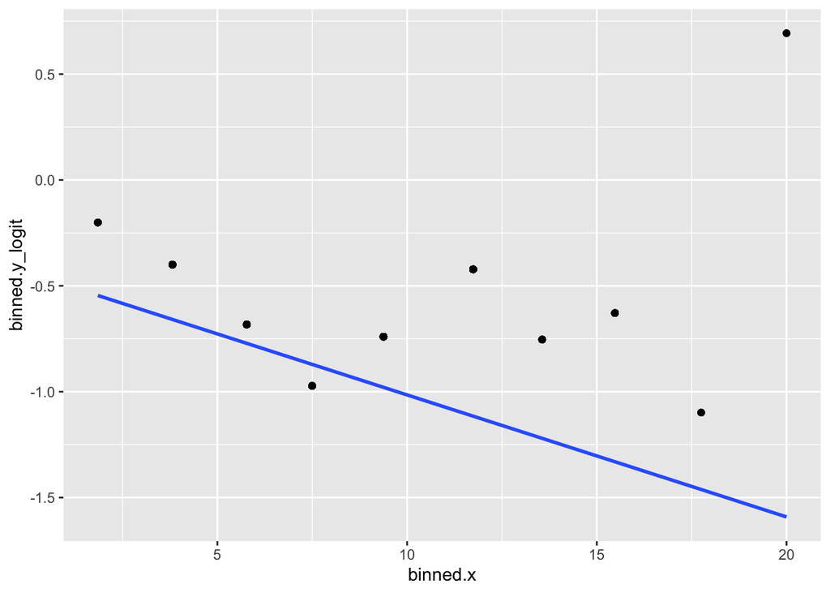

```r
# Code from 18-simplelogistic-lab activity to generate x and y values for plot to check for linearity
data_bin <- data_binary %>%
  # Break HRSLEEP into 10 bins
  mutate(HRSLEEP_group = cut(HRSLEEP, breaks=10)) %>%
  group_by(HRSLEEP_group) %>%
  # calculate mean HRSLEEP value and proportion obese in each bin
  mutate(binned.y = mean(BMI_binary), binned.x = mean(HRSLEEP)) %>%
  # transform binned.y from proportion to log(odds)
  mutate(binned.y_logit = logit(binned.y))

# Create plot of log(odds) verus age
ggplot(data_bin, aes(x = binned.x, y = binned.y_logit)) +
  geom_point() +
  geom_smooth(method = lm, se = FALSE)
```

## Randomness

Obviously, individuals are not assigned BMIs by a spinner model, but since we have a random sample, the randomness assumption is met.

## Independence

As established above for the linear regression model, the independence assumption is reasonable for this data set.

# Significance Tests:

## Z-test for slope:

$\beta_1$:

$H_0: \beta_1 = 0$

$H_a: \beta_1 \ne 0$

$\alpha = 0.05$

z-value = -5.438

p-value = 5.38e-08

Since our p-value of 5.38e-08 is less than 0.05, we have strong evidence to reject the null hypothesis and conclude that there is a significant relationship between the number of hours of sleep and individual gets per night and their likelihood of having a BMI that classifies them as obese, adjusting for worry frequency and the rest of our confounding variables.

$\beta_2$:

$H_0: \beta_2 = 0$

$H_a: \beta_2 \ne 0$

$\alpha = 0.05$

z-value = -2.243 0.024896

p-value = 0.024896

Since our p-value of 0.024896 is less than 0.05, we have strong evidence to reject the null hypothesis and conclude that on average, adjusting for hours of sleep and the rest of our confounding variables, an individual’s likelihood of being obese differs depending on whether they worry daily or not.

$\beta_3$:

$H_0: \beta_3 = 0$

$H_a: \beta_3 \ne 0$

$\alpha = 0.05$

z-value = 2.445 0.014482

p-value = 0.014482

Since our p-value of 0.014482 is less than 0.05, we have strong evidence to reject the null hypothesis and conclude that adjusting for our confounding variables, on average, the rate of change of an individual’s odds of obesity as hours of sleep increases differs for individuals who worry daily versus those who do not.

## 95% Confidence Intervals

$\beta_1$: CI = (0.9127667, 0.9579719)

We are 95% confident that for each hour increase in the number of hours and individual sleeps per night, an individual’s odds of being classified as obese will decrease by a factor of between 0.913 and 0.958, on average, from the average odds of being obese for an individual who gets one fewer hour of sleep per night, adjusting for worry frequency and the rest of our counfounding variables. Since our confidence interval does not include 1, this indicates that there is a significant relationship between hours of sleep and likelihood of being obese.

$\beta_2$: CI = (0.4222978, 0.9436237)

We are 95% confident that adjusting for hours of sleep and the other confounding variables, on average, the odds of being obese for an individual who worries daily decreases by a factor between 0.422 and 0.943 from the odds of being obese for an individual who does not worry daily. Since our confidence interval does not include 1, this indicates that there is a significant difference in the odds of being obese between individuals who worry daily and those who do not.

$\beta_3$: CI = (1.0141055, 1.1369377)

We are 95% confident that adjusting for our confounding variables, the magnitude of the average rate of change of the odds of obesity as hours of sleep increases for an individual who worries daily is between 1.014 and 1.137 times the rate of change of an individual who does not worry daily. Since our confidence interval does not include 1, this indicates that the average rate of change of the odds of obesity differs significantly for individuals who worry daily versus those who do not.

```r
exp(confint(model_logistic))
```

```
##                                 2.5 %    97.5 %
## (Intercept)                 0.4762299 1.0059015
## HRSLEEP                     0.9127667 0.9579719
## worfreq_binary              0.4222978 0.9436237
## I(HRSLEEP * worfreq_binary) 1.0141055 1.1369377
## log(AGE)                    0.9246919 1.0902518
## activity_score              1.0003219 1.0004349
## SEX                         0.9332604 1.0573097
## income_high                 0.8831615 1.0341245
## income_middle               1.1280812 1.3209903
## health_binary               0.5785509 0.6976153
## race_asian                  0.3040884 0.4387308
## race_black                  1.2130742 1.4601232
## race_na                     1.1866008 1.9403297
```

## Likelihood Ratio Test

$H_0: \beta_i = 0$

$H_a: \beta_i \ne 0$

$\alpha = 0.05$

```r
# Load necessary package
require(lmtest)
lrtest(model_logistic)
```

```
## Likelihood ratio test
##
## Model 1: BMI_binary ~ HRSLEEP + worfreq_binary + I(HRSLEEP * worfreq_binary) +
##     log(AGE) + activity_score + SEX + income_high + income_middle +
##     health_binary + race_asian + race_black + race_na
## Model 2: BMI_binary ~ 1
##   #Df LogLik  Df  Chisq Pr(>Chisq)
## 1  13 -11800
## 2   1 -12154 -12 708.58  < 2.2e-16 ***
## ---
## Signif. codes:  0 '***' 0.001 '**' 0.01 '*' 0.05 '.' 0.1 ' ' 1
```

The $-2log(L)$ values are $-2\cdot -12154 = 24308$ and $-2\cdot -11800 = 23600$ for the null model and full logistic model, respectively. This yields a G-statistic of 24308 - (23600) = 708. Compared to a chi-distribution with 12 degrees of freedom, the p-value is less than 2.2e-16, which is significant at the alpha = 0.05 level. We therefore reject the null hypothesis and conclude that the multiple logistic regression model based on sleep, worry frequency, and the interaction between sleep and worry frequency is effective at explaining the probability of being obese.

```r
# code from Logistic Regression visualization practice activity 4/20/20
preds <- augment(x=model_logistic, type.predict = "response") %>%
  mutate(lci=`.fitted`-(1.96*`.se.fit`),
         uci=`.fitted`+(1.96*`.se.fit`)) %>%
  rename(prob=`.fitted`)

probs<- preds %>%
  select(prob,lci,uci, worfreq_binary , HRSLEEP, BMI_binary)

library(InformationValue)
Concordance(probs$BMI_binary, probs$prob)
```

```
## $Concordance
## [1] 0.6174937
##
## $Discordance
## [1] 0.3825063
##
## $Tied
## [1] -5.551115e-17
##
## $Pairs
## [1] 83039968
```